# Texas2022_analysis_working

#### Weslaco

```r
## Now, just with the WESLACO site ##

# filter data to just Weslaco
parasite_data_wes <- parasite_data %>%
  filter(site.id == "Weslaco")

# species model
mod_para_species_wes <- glmmTMB(totalpara ~ species,
  family = "nbinom2",
  ziformula = ~.,
  data = parasite_data
)

summary(mod_para_species_wes) # yep, no significant species differences
```

```
##  Family: nbinom2  ( log )
## Formula:          totalpara ~ species
## Zero inflation:             ~.
## Data: parasite_data
##
##      AIC      BIC   logLik deviance df.resid
##   1024.4   1038.7   -507.2   1014.4      123
##
##
## Dispersion parameter for nbinom2 family (): 0.28
##
## Conditional model:
##                     Estimate Std. Error z value Pr(>|z|)
## (Intercept)           3.4996     0.2286  15.309   <2e-16 ***
## speciesP. latipinna   0.6274     0.3624   1.731   0.0834 .
## ---
## Signif. codes:  0 '***' 0.001 '**' 0.01 '*' 0.05 '.' 0.1 ' ' 1
##
## Zero-inflation model:
##                     Estimate Std. Error z value Pr(>|z|)
## (Intercept)           -19.91    4368.24  -0.005    0.996
## speciesP. latipinna    18.01    4368.24   0.004    0.997
```

```r
# just to be extra sure, I also ran an lrt on the weslaco species model versus a null model set to the intercept (I think my notation is correct, using 1 to set the intercept)
mod_para_null_wes <- glmmTMB(totalpara ~ 1,
  family = "nbinom2",
  ziformula = ~.,
  data = parasite_data
)

lrtest(mod_para_species_wes, mod_para_null_wes) # no significance, suggesting that the species effect is indistinguishable from our null
```

```
## Likelihood ratio test
##
## Model 1: totalpara ~ species
## Model 2: totalpara ~ 1
##   #Df  LogLik Df  Chisq Pr(>Chisq)
## 1   5 -507.20
## 2   3 -509.01 -2 3.6158      0.164
```

#### Brownsville

```r
## Now, just with the Brownsville site ##

# filter data to just Brownsville
parasite_data_br <- parasite_data %>%
  filter(site.id == "Brownsville")

# species model
mod_para_species_br <- glmmTMB(totalpara ~ species,
  family = "nbinom2",
  ziformula = ~.,
  data = parasite_data
)

summary(mod_para_species_br) # yep, no significant species differences
```

```
##  Family: nbinom2  ( log )
## Formula:          totalpara ~ species
## Zero inflation:             ~.
## Data: parasite_data
##
##      AIC      BIC   logLik deviance df.resid
##   1024.4   1038.7   -507.2   1014.4      123
##
##
## Dispersion parameter for nbinom2 family (): 0.28
##
## Conditional model:
##                     Estimate Std. Error z value Pr(>|z|)
## (Intercept)           3.4996     0.2286  15.309   <2e-16 ***
## speciesP. latipinna   0.6274     0.3624   1.731   0.0834 .
## ---
## Signif. codes:  0 '***' 0.001 '**' 0.01 '*' 0.05 '.' 0.1 ' ' 1
##
## Zero-inflation model:
##                     Estimate Std. Error z value Pr(>|z|)
## (Intercept)           -19.91    4368.24  -0.005    0.996
## speciesP. latipinna    18.01    4368.24   0.004    0.997
```

```r
# just to be extra sure, I also ran an lrt on the brownsville species model versus a null model set to the intercept (I think my notation is correct, using 1 to set the intercept)
mod_para_null_br <- glmmTMB(totalpara ~ 1,
  family = "nbinom2",
  ziformula = ~.,
  data = parasite_data
)

lrtest(mod_para_species_br, mod_para_null_br) # no significance, suggesting that the species effect is indistinguishable from our null
```

```
## Likelihood ratio test
##
## Model 1: totalpara ~ species
## Model 2: totalpara ~ 1
##   #Df  LogLik Df  Chisq Pr(>Chisq)
## 1   5 -507.20
## 2   3 -509.01 -2 3.6158      0.164
```

### Behavior

Ok now we’d need to see if behavior overall, before the stimulus, and after the stimulus differs between species and parasite load. We may have to just look at one site, Weslaco since the data is more balanced between species there.

Let’s look at the time spent in the open after the startle stimulus, as that is the most relevant (since parasites can affect anti-pred behavior)

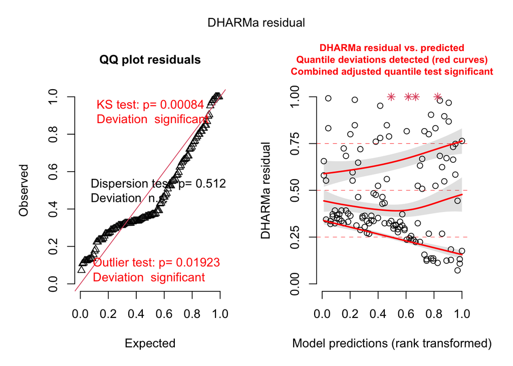

```r
# FULL model, with three-way interaction
mod_beh_full <- lm(total.time.open.after ~ species * site.id * totalpara + standard.length,
                   data = all_data)

# to run all the tests in DHARMa, you first have to simulate your residuals
sim.mod_beh <- DHARMa::simulateResiduals(mod_beh_full)

# then you can plot them
plot(sim.mod_beh) # these both look not great
```

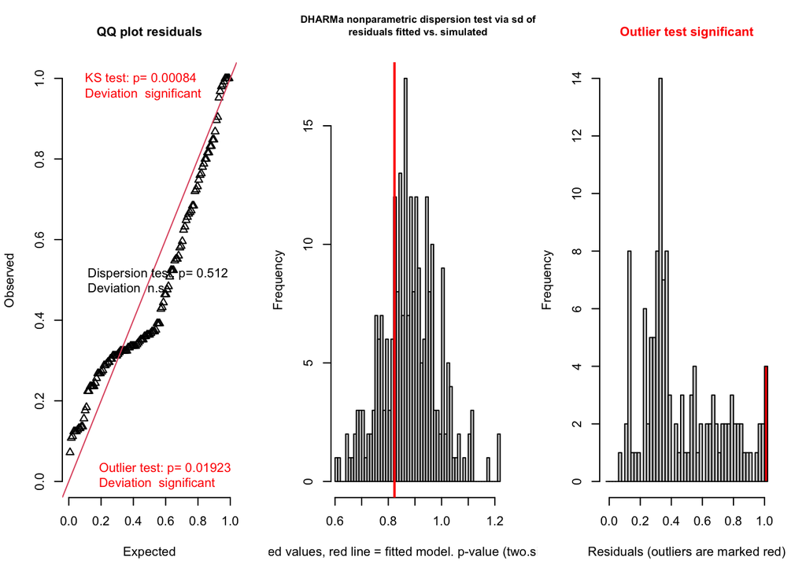

```
## $uniformity
##
##  Asymptotic one-sample Kolmogorov-Smirnov test
##
## data:  simulationOutput$scaledResiduals
## D = 0.17493, p-value = 0.0008424
## alternative hypothesis: two-sided
##
##
## $dispersion
##
##  DHARMa nonparametric dispersion test via sd of residuals fitted vs.
##  simulated
##
## data:  simulationOutput
## dispersion = 0.93602, p-value = 0.512
## alternative hypothesis: two.sided
##
##
## $outliers
##
##  DHARMa outlier test based on exact binomial test with approximate
##  expectations
##
## data:  simulationOutput
## outliers at both margin(s) = 4, observations = 127, p-value = 0.01923
## alternative hypothesis: true probability of success is not equal to 0.007968127
## 95 percent confidence interval:
##  0.008647004 0.078679127
## sample estimates:
## frequency of outliers (expected: 0.00796812749003984 )
##                                             0.03149606
```

```r
# gives you a bunch of tests of dispersion etc
DHARMa::testResiduals(sim.mod_beh) # dispersion looks ok, but the QQ plot is bad and outlier test is significant
```

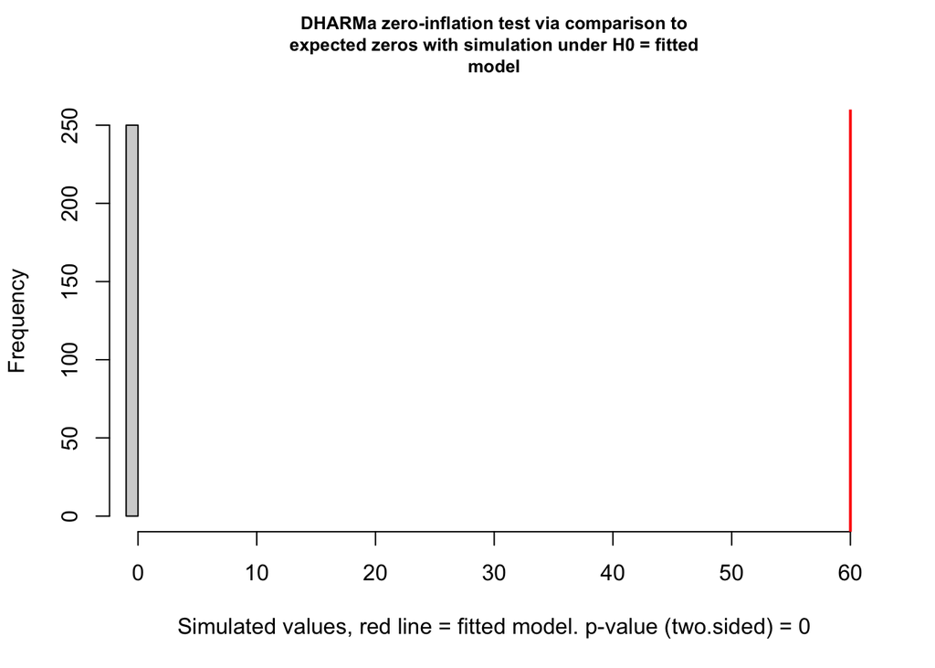

```
##
##  DHARMa zero-inflation test via comparison to expected zeros with
##  simulation under H0 = fitted model
##
## data:  simulationOutput
## ratioObsSim = Inf, p-value < 2.2e-16
## alternative hypothesis: two.sided
```

```r
# yes we can see that the data is super zero inflated
DHARMa::testZeroInflation(sim.mod_beh) # yep, zero inflated
```

Ok now let’s try to fit some different models.

```r
mod_beh_poisson <- glmmTMB(total.time.open.after ~ species * site.id * totalpara + standard.length,
  family = "poisson",
  ziformula = ~.,
  data = all_data
)
mod_beh_nbin <- glmmTMB(total.time.open.after ~ species * site.id * totalpara + standard.length,
  family = "nbinom2",
  ziformula = ~.,
  data = all_data
)

#
check_overdispersion(mod_beh_poisson) # data is over dispersed
```

```
## # Overdispersion test
##
##  dispersion ratio =   2.067
##           p-value = < 0.001
```

```
## Overdispersion detected.
```

```r
check_overdispersion(mod_beh_nbin) # data is not over dispersed
```

```
## # Overdispersion test
##
##  dispersion ratio = 0.795
##           p-value = 0.616
```

```
## No overdispersion detected.
```

```r
lrtest(mod_beh_poisson, mod_beh_nbin) # there is a sig difference between the two
```

```
## Likelihood ratio test
##
## Model 1: total.time.open.after ~ species * site.id * totalpara + standard.length
## Model 2: total.time.open.after ~ species * site.id * totalpara + standard.length
##   #Df   LogLik Df  Chisq Pr(>Chisq)
## 1  18 -2990.01
## 2  19  -477.45  1 5025.1  < 2.2e-16 ***
## ---
## Signif. codes:  0 '***' 0.001 '**' 0.01 '*' 0.05 '.' 0.1 ' ' 1
```

```r
# checking AIC
anova(mod_beh_poisson, mod_beh_nbin) # nbin model is much lower
```

```
## Data: all_data
## Models:
## mod_beh_poisson: total.time.open.after ~ species * site.id * totalpara + standard.length, zi=~., disp=~1
## mod_beh_nbin: total.time.open.after ~ species * site.id * totalpara + standard.length, zi=~., disp=~1
##                 Df    AIC    BIC   logLik deviance  Chisq Chi Df Pr(>Chisq)
## mod_beh_poisson 18 6016.0 6067.2 -2990.01   5980.0
## mod_beh_nbin    19  992.9 1046.9  -477.45    954.9 5025.1      1  < 2.2e-16 ***
## ---
## Signif. codes:  0 '***' 0.001 '**' 0.01 '*' 0.05 '.' 0.1 ' ' 1
```

Ok, let’s move forward with the nbin model. Time for some backwards model selection.

```r
# interaction model
mod_beh_nbin <- glmmTMB(total.time.open.after ~ species * site.id * totalpara + standard.length,
  family = "nbinom2",
  ziformula = ~.,
  data = all_data
)

# removing species interaction
mod_spcomb_nbin <- glmmTMB(total.time.open.after ~ species + site.id * totalpara + standard.length,
  family = "nbinom2",
  ziformula = ~.,
  data = all_data
)

# test 2-way with log likelihood ratio test
lrtest(mod_beh_nbin, mod_spcomb_nbin) # hmmmm this looks weird...
```

```
## Likelihood ratio test
##
## Model 1: total.time.open.after ~ species * site.id * totalpara + standard.length
## Model 2: total.time.open.after ~ species + site.id * totalpara + standard.length
##   #Df  LogLik Df Chisq Pr(>Chisq)
## 1  19 -477.45
## 2  13 -482.99 -6 11.08    0.08593 .
## ---
## Signif. codes:  0 '***' 0.001 '**' 0.01 '*' 0.05 '.' 0.1 ' ' 1
```

```r
# combined model
mod_beh_combined_nbin <- glmmTMB(total.time.open.after ~ species + site.id + totalpara + standard.length,
  family = "nbinom2",
  ziformula = ~.,
  data = all_data
)

# test species effect
lrtest(mod_beh_nbin, mod_beh_combined_nbin) # No difference, so let's see how the combined does compared to a reduced model
```

```
## Likelihood ratio test
##
## Model 1: total.time.open.after ~ species * site.id * totalpara + standard.length
## Model 2: total.time.open.after ~ species + site.id + totalpara + standard.length
##   #Df  LogLik Df  Chisq Pr(>Chisq)
## 1  19 -477.45
## 2  11 -484.04 -8 13.171     0.1061
```

```r
# no length
mod_beh_nolength_nbin <- glmmTMB(total.time.open.after ~ species + site.id + totalpara,
  family = "nbinom2",
  ziformula = ~.,
  data = all_data
)

# test length effect
lrtest(mod_beh_nolength_nbin, mod_beh_combined_nbin) # no sig diff, let's drop length
```

```
## Likelihood ratio test
##
## Model 1: total.time.open.after ~ species + site.id + totalpara
## Model 2: total.time.open.after ~ species + site.id + totalpara + standard.length
##   #Df  LogLik Df  Chisq Pr(>Chisq)
## 1   9 -486.68
## 2  11 -484.04  2 5.2746    0.07155 .
## ---
## Signif. codes:  0 '***' 0.001 '**' 0.01 '*' 0.05 '.' 0.1 ' ' 1
```

```r
# just because I'm curious, let's try removing site too
mod_beh_nosite_nbin <- glmmTMB(total.time.open.after ~ species + totalpara,
  family = "nbinom2",
  ziformula = ~.,
  data = all_data
)

# test site.id effect
lrtest(mod_beh_nosite_nbin, mod_beh_nolength_nbin) # no there is a sig diff, so let's keep site
```

```
## Likelihood ratio test
##
## Model 1: total.time.open.after ~ species + totalpara
## Model 2: total.time.open.after ~ species + site.id + totalpara
##   #Df  LogLik Df  Chisq Pr(>Chisq)
## 1   7 -490.63
## 2   9 -486.68  2 7.9014    0.01924 *
## ---
## Signif. codes:  0 '***' 0.001 '**' 0.01 '*' 0.05 '.' 0.1 ' ' 1
```

Ok so we’re moving forward with a model without interactions, including site, species, and total parasites as predictors, but not including length. Let’s check those assumptions.

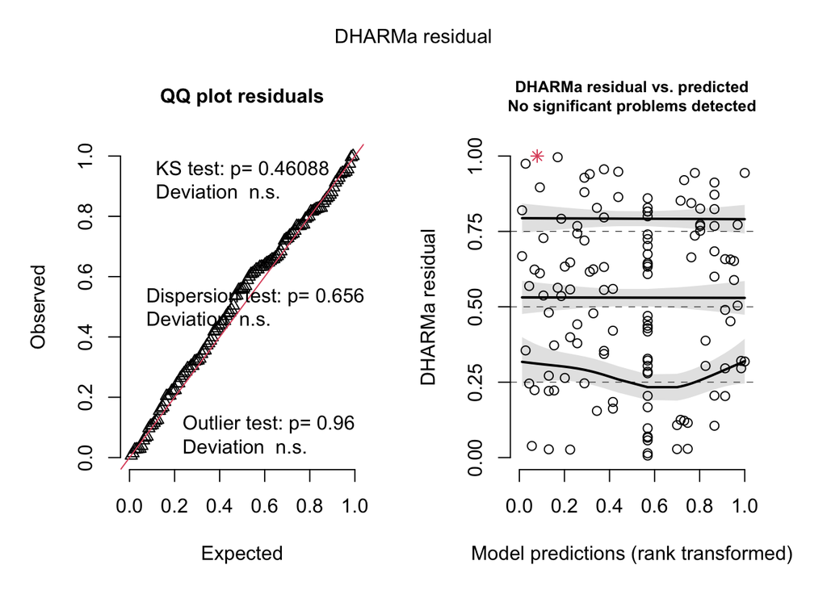

```r
# checking assumptions for the combined, no length model
# First we have to simulate your residuals
sim.output <- DHARMa::simulateResiduals(mod_beh_nolength_nbin)

# then you can plot them
plot(sim.output) # these look pretty good!
```

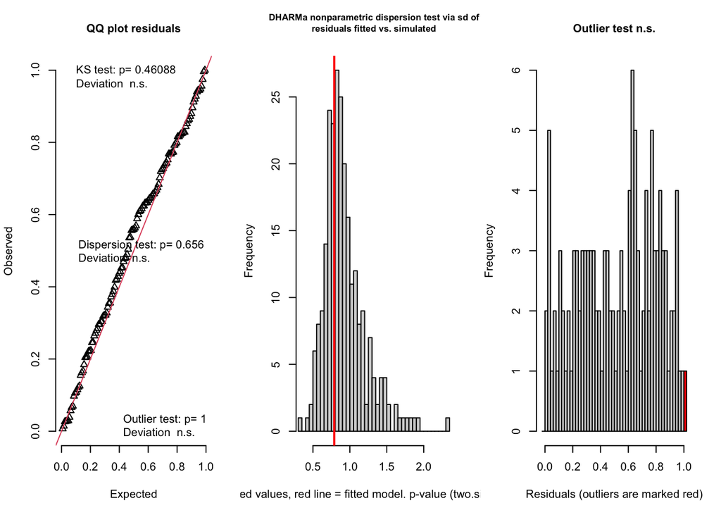

```
## $uniformity
##
##  Asymptotic one-sample Kolmogorov-Smirnov test
##
## data:  simulationOutput$scaledResiduals
## D = 0.075685, p-value = 0.4609
## alternative hypothesis: two-sided
##
##
## $dispersion
##
##  DHARMa nonparametric dispersion test via sd of residuals fitted vs.
##  simulated
##
## data:  simulationOutput
## dispersion = 0.84943, p-value = 0.656
## alternative hypothesis: two.sided
##
##
## $outliers
##
##  DHARMa bootstrapped outlier test
##
## data:  simulationOutput
## outliers at both margin(s) = 1, observations = 127, p-value = 1
## alternative hypothesis: two.sided
##  percent confidence interval:
##  0.00000000 0.02775591
## sample estimates:
## outlier frequency (expected: 0.00677165354330709 )
##                                        0.007874016
```

```r
# gives you a bunch of tests of dispersion etc
DHARMa::testResiduals(sim.output) # nice!
```

```r
# from poking around, it seems like estimating overdispersion is how we evaluate goodness of fit (versus an r-squared). Not sure if that is the correct move, but here we go. I also used this earlier on to evaluate whether I should use a negbin or poisson.
check_overdispersion(mod_beh_nolength_nbin) # no overdispersion detected. dispersion ratio = 0.849, p = 0.656
```

```
## # Overdispersion test
##
##  dispersion ratio = 0.849
##           p-value = 0.656
```

```
## No overdispersion detected.
```

```r
summary(mod_beh_nolength_nbin) # species and site are significant predictors of time spent in the open, but not the number of parasites. Neat!
```

```
##  Family: nbinom2  ( log )
## Formula:          total.time.open.after ~ species + site.id + totalpara
## Zero inflation:                         ~.
## Data: all_data
##
##      AIC      BIC   logLik deviance df.resid
##    991.4   1016.9   -486.7    973.4      118
##
##
## Dispersion parameter for nbinom2 family (): 1.44
##
## Conditional model:
##                      Estimate Std. Error z value Pr(>|z|)
## (Intercept)          5.707420   0.290608  19.640   <2e-16 ***
## speciesP. latipinna -0.242366   0.208730  -1.161   0.2456
## site.idWeslaco      -0.491179   0.275555  -1.783   0.0747 .
## totalpara           -0.002049   0.001137  -1.802   0.0715 .
## ---
## Signif. codes:  0 '***' 0.001 '**' 0.01 '*' 0.05 '.' 0.1 ' ' 1
##
## Zero-inflation model:
##                      Estimate Std. Error z value Pr(>|z|)
## (Intercept)         -0.389392   0.551167  -0.706  0.47989
## speciesP. latipinna  1.405873   0.438779   3.204  0.00136 **
## site.idWeslaco      -1.008341   0.474234  -2.126  0.03348 *
## totalpara           -0.001915   0.002399  -0.798  0.42471
## ---
## Signif. codes:  0 '***' 0.001 '**' 0.01 '*' 0.05 '.' 0.1 ' ' 1
```